# Linear Regression: Model Specification, Comparison, and Interpretation

## 10.1 Interpret the comparisons

```r
# Identify the model with the highest R-squared
best_R2_model <- model_performance %>%
  dplyr::slice_max(r.squared, n = 1, with_ties = FALSE)

best_R2_value <- best_R2_model$r.squared

# Calculate the R-squared improvement for M1
# Calculate R-squared improvements for each model
m1_delta <- model_performance$delta_R2[
  model_performance$Model == "M1"
]

m2_delta <- model_performance$delta_R2[
  model_performance$Model == "M2"
]

m3_delta <- model_performance$delta_R2[
  model_performance$Model == "M3"
]

# Identify the model with the highest adjusted R-squared
best_adjusted_model <- model_performance %>%
  dplyr::slice_max(adj.r.squared, n = 1, with_ties = FALSE)

# Display the key results
best_R2_model %>%
  dplyr::select(Model, r.squared, adj.r.squared, RMSE)
```

```
# A tibble: 1 × 4
  Model r.squared adj.r.squared  RMSE
  <chr>     <dbl>         <dbl> <dbl>
1 M3        0.708         0.675  6.46
```

```r
best_adjusted_model %>%
  dplyr::select(Model, r.squared, adj.r.squared, RMSE)
```

```
# A tibble: 1 × 4
  Model r.squared adj.r.squared  RMSE
  <chr>     <dbl>         <dbl> <dbl>
1 M2        0.708         0.686  6.47
```

```r
# Display incremental improvements
combined_model_table %>%
  dplyr::select(Model, delta_R2, F_statistic, P_value, RMSE)
```

```
  Model     delta_R2 F_statistic      P_value      RMSE
1    M0           NA          NA           NA 11.967967
2    M1 0.6813141641 60.72560389 2.883919e-08  6.756188
3    M2 0.0267010317  2.37986580 1.349930e-01  6.466965
4    M3 0.0002764121  0.02463664 8.764884e-01  6.463903
```

1. Which model explains the largest proportion of variation in rating?

Model M3 explains the largest proportion of variation in rating, with an R² of 0.7083 (70.83%). However, its improvement over M2 is extremely small, suggesting that adding raises contributes very little additional explanatory power.

2. How does adjusted R² change as predictors are added?

Adjusted R² increases from 0.6699 in M1 to 0.6864 in M2, indicating a modest improvement after adding learning. However, it decreases to 0.6746 in M3, suggesting that adding raises does not justify the increased model complexity.

3. How much additional variation does each successive model explain?
- M0 to M1: R² increases by 68.13 percentage points.
- M1 to M2: R² increases by 2.67 percentage points.
- M2 to M3: R² increases by only 0.03 percentage points. These results indicate that complaints accounts for most of the explained variation, while learning provides a relatively small additional contribution and raises contributes almost nothing.
4. Which additions produce statistically significant improvements in fit?

Overall conclusion: Overall, complaints is the strongest contributor to explaining variation in rating. Although adding learning produces a small increase in R², this improvement is not statistically significant. Adding raises provides virtually no additional explanatory value. Therefore, M1 may be preferred as a more parsimonious model, despite M3 having the highest numerical R².

# 11 Evaluate regression diagnostics

## 11.1 Select a candidate model for diagnostic evaluation

The model with the highest adjusted R-squared among M1, M2, and M3 is selected as the initial candidate.

This is a provisional choice. The diagnostic results and substantive interpretability must also be considered before finalizing the preferred model.

```r
candidate_name <- model_performance %>%
  filter(Model != "M0") %>%
  slice_max(
    adj.r.squared,
    n = 1,
    with_ties = FALSE
  ) %>%
  pull(Model)

candidate_model <- switch(
  candidate_name,
  "M1" = M1,
  "M2" = M2,
  "M3" = M3
)

candidate_name
```

```
[1] "M2"
```

```r
summary(candidate_model)
```

```
Call:
lm(formula = rating ~ complaints + learning, data = dat)

Residuals:
     Min       1Q   Median       3Q      Max
-11.5568  -5.7331   0.6701   6.5341  10.3610

Coefficients:
            Estimate Std. Error t value Pr(>|t|)
(Intercept)   9.8709     7.0612   1.398    0.174
complaints    0.6435     0.1185   5.432 9.57e-06 ***
learning      0.2112     0.1344   1.571    0.128
---
Signif. codes:  0 '***' 0.001 '**' 0.01 '*' 0.05 '.' 0.1 ' ' 1

Residual standard error: 6.817 on 27 degrees of freedom
Multiple R-squared:  0.708, Adjusted R-squared:  0.6864
F-statistic: 32.74 on 2 and 27 DF,  p-value: 6.058e-08
```

## 11.2 Examine the regression assumptions

Standard regression diagnostic plots are used to examine linearity, residual normality, homoscedasticity, and potentially influential observations.

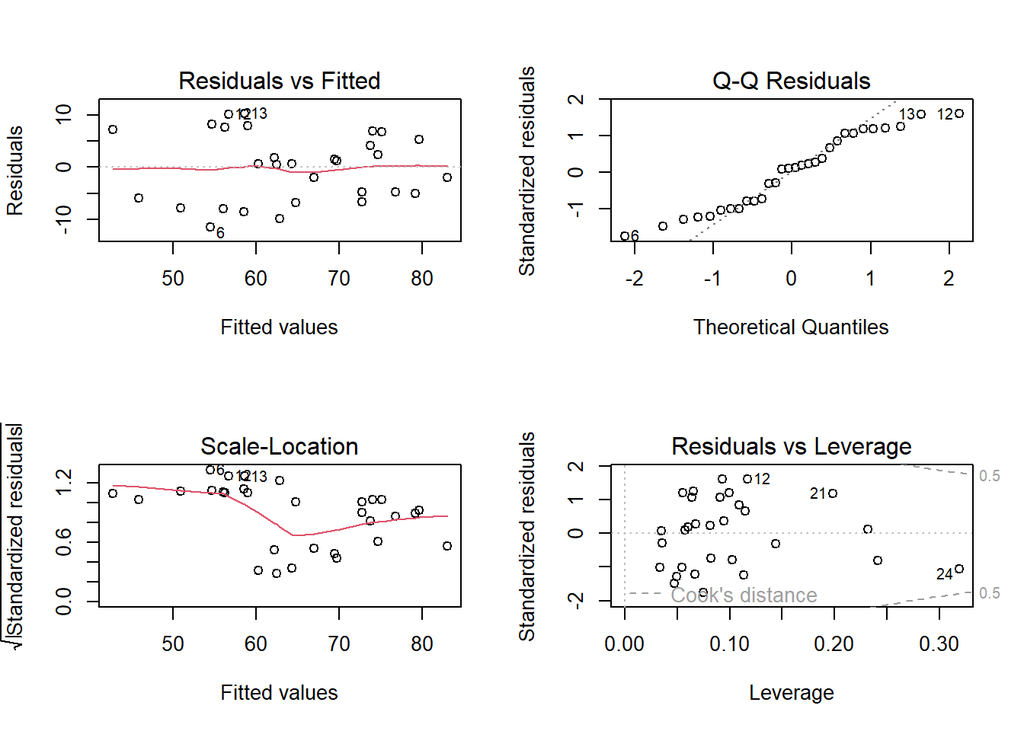

```r
par(mfrow = c(2, 2))
plot(candidate_model)
```

[figure not shown]

```r
par(mfrow = c(1, 1))

performance::check_model(candidate_model)
```

The `check_model()` function provides an additional visual assessment of the regression assumptions.

```r
performance::check_collinearity(candidate_model)
```

```
# Check for Multicollinearity

Low Correlation

       Term  VIF   VIF 95% CI adj. VIF Tolerance Tolerance 95% CI
 complaints 1.55 [1.10, 2.25]     1.25      0.64     [0.44, 0.91]
   learning 1.55 [1.10, 2.25]     1.25      0.64     [0.44, 0.91]
```

## 11.3 Examine multicollinearity

Multicollinearity can make it difficult to estimate the unique contribution of individual predictors.

```r
if (length(coef(candidate_model)) > 2) {

  performance::check_collinearity(candidate_model)

} else {

  cat(
    "The candidate model contains only one predictor. ",
    "Multicollinearity among multiple predictors is not applicable."
  )

}
```

```
# Check for Multicollinearity

Low Correlation

       Term  VIF   VIF 95% CI adj. VIF Tolerance Tolerance 95% CI
 complaints 1.55 [1.10, 2.25]     1.25      0.64     [0.44, 0.91]
   learning 1.55 [1.10, 2.25]     1.25      0.64     [0.44, 0.91]
```

## 11.4 Report your diagnostic findings

### 11.4.1 Diagnostic Findings

Diagnostic plots for the selected model (M2), which included complaints and learning as predictors, indicated that the linearity assumption was reasonably satisfied, with no strong systematic pattern in the residuals. However, minor deviations from normality were observed at the tails of the Q-Q plot, and the Scale-Location plot suggested some variation in residual spread, indicating possible mild heteroscedasticity. Although observation 24 showed relatively high leverage, it did not appear to be strongly influential based on Cook’s distance. Furthermore, multicollinearity was not a major concern, as the VIF values for both predictors were below 5. The observed and model-predicted distributions were also reasonably similar. Overall, these findings suggest that the model is reasonably appropriate, although the potential deviations from normality and constant variance warrant some caution when interpreting the results. These limitations do not invalidate the model, but they suggest that the estimated relationships should be interpreted cautiously.

# 12 Select and report your preferred model

## 12.1 Select a model

The candidate model is initially selected based on adjusted R-squared. The final decision should also consider the nested-model F-tests, changes in R-squared, RMSE, model complexity, diagnostic findings, and substantive interpretability.

The following object identifies the preferred model. If your diagnostic assessment supports a different model, change `preferred_model_name` to `"M1"`, `"M2"`, or `"M3"` before rendering the report.

```r
# Select M1 as the preferred model

preferred_model_name <- "M1"

preferred_model <- switch(
  preferred_model_name,
  "M1" = M1,
  "M2" = M2,
  "M3" = M3
)

preferred_model_name
```

```
[1] "M1"
```

```r
summary(preferred_model)
```

```
Call:
lm(formula = rating ~ complaints, data = dat)

Residuals:
     Min       1Q   Median       3Q      Max
-12.8799  -5.9905   0.1783   6.2978   9.6294

Coefficients:
            Estimate Std. Error t value Pr(>|t|)
(Intercept) 14.37632    6.61999   2.172   0.0385 *
complaints   0.75461    0.09753   7.737 1.99e-08 ***
---
Signif. codes:  0 '***' 0.001 '**' 0.01 '*' 0.05 '.' 0.1 ' ' 1

Residual standard error: 6.993 on 28 degrees of freedom
Multiple R-squared:  0.6813,    Adjusted R-squared:  0.6699
F-statistic: 59.86 on 1 and 28 DF,  p-value: 1.988e-08
```

However, the final choice should also reflect whether the additional predictors provide statistically significant improvements, whether RMSE decreases meaningfully, and whether the diagnostic plots indicate serious violations of regression assumptions.

A more complex model is not necessarily preferable if the additional predictors provide little improvement in model fit or make the interpretation less precise.

## 12.2 Create a coefficient table

The `tidy()` function from the `broom` package is used to extract the estimated regression coefficients and their 95% confidence intervals.

```r
selected_tidy <- broom::tidy(
  preferred_model,
  conf.int = TRUE,
  conf.level = 0.95
)

coefficient_table <- selected_tidy %>%
  dplyr::select(
    Predictor = term,
    Estimate = estimate,
    Standard_Error = std.error,
    CI_Lower = conf.low,
    CI_Upper = conf.high,
    p_value = p.value
  )

coefficient_table %>%
  gt::gt() %>%
  gt::fmt_number(
    columns = c(
      Estimate,
      Standard_Error,
      CI_Lower,
      CI_Upper
    ),
    decimals = 3
  ) %>%
  gt::fmt_number(
    columns = p_value,
    decimals = 4
  ) %>%
  gt::cols_label(
    Predictor = "Predictor",
    Estimate = "Coefficient",
    Standard_Error = "Standard Error",
    CI_Lower = "95% CI Lower",
    CI_Upper = "95% CI Upper",
    p_value = "p-value"
  ) %>%
  gt::tab_header(
    title = "Regression Coefficients",
    subtitle = paste(
      "Preferred model:",
      preferred_model_name
    )
  )
```

Regression Coefficients

Preferred model: M1

| Predictor | Coefficient | Standard Error | 95% CI Lower | 95% CI Upper | p-value |
| --- | --- | --- | --- | --- | --- |
| (Intercept) | 14.376 | 6.620 | 0.816 | 27.937 | 0.0385 |
| complaints | 0.755 | 0.098 | 0.555 | 0.954 | 0.0000 |

## 12.3 Interpret the coefficients

```r
interpret_coefficient <- function(variable) {

  result <- selected_tidy %>%
    dplyr::filter(term == variable)

  if (nrow(result) == 0) {
    return(NULL)
  }

  estimate <- result %>%
    dplyr::pull(estimate)

  lower <- result %>%
    dplyr::pull(conf.low)

  upper <- result %>%
    dplyr::pull(conf.high)

  direction <- if (estimate > 0) {
    "positive"
  } else if (estimate < 0) {
    "negative"
  } else {
    "approximately zero"
  }

  paste0(
    "For ", variable,
    ", the estimated coefficient is ",
    round(estimate, 3),
    ", indicating a ", direction,
    " association with overall ratings. ",
    "A one-unit increase in complaints is associated with an estimated ",
    round(estimate, 3),
    " point increase in overall ratings. ",
    "Since M1 includes only one predictor, no other predictors are held constant. ",
    "The 95% confidence interval ranges from ",
    round(lower, 3),
    " to ",
    round(upper, 3),
    "."
  )
}

coefficient_interpretations <- c(
  interpret_coefficient("complaints")
)

cat(
  paste(
    coefficient_interpretations,
    collapse = "\n\n"
  )
)
```

[output not shown]

1. Direction of the association

The regression coefficient for complaints was positive, indicating a positive association between complaints and overall ratings. This suggests that departments with higher complaint scores tended to have higher overall rating scores.

2. Interpretation of the coefficient in the original units

Since M1 includes complaints as the only predictor, no other explanatory variables were held constant. Therefore, the coefficient represents the unadjusted association between complaints and overall ratings.

## 12.4 Summarize model performance

The following values are extracted from the selected model.

```r
selected_performance <- model_performance %>%
  dplyr::filter(Model == preferred_model_name)

selected_r2 <- selected_performance %>%
  dplyr::pull(r.squared)

selected_adjusted_r2 <- selected_performance %>%
  dplyr::pull(adj.r.squared)

selected_rmse <- selected_performance %>%
  dplyr::pull(RMSE)
```

```r
model_R2 <- summary(preferred_model)$r.squared

model_adjusted_R2 <- summary(preferred_model)$adj.r.squared

model_RMSE <- sqrt(mean(residuals(preferred_model)^2))
```

# 13 Discuss findings and limitations

The analysis examines the relative contributions of complaint handling, learning opportunities, and pay increases to overall workplace ratings.

1. Complaint Handling

Complaint handling appeared to be the most important predictor of overall workplace ratings among the three variables examined. In Model M1, complaints explained approximately 68.13% of the variation in overall ratings (R² = 0.6813). The association was positive and statistically significant (p < 0.001), suggesting that departments with higher complaint-handling scores tended to have higher overall workplace ratings. Furthermore, complaints remained a statistically significant predictor when learning opportunities and pay increases were added to the model.

2. Learning Opportunities

3. Pay Increases

Pay increases contributed very little additional explanatory power. When raises were added to M2 to create M3, R² increased by only approximately 0.03 percentage points. This improvement was not statistically significant (p = 0.876). Therefore, raises did not meaningfully improve the explanatory performance of the model after accounting for complaints and learning.

4. Overall Comparison

Overall, complaint handling demonstrated the strongest statistical association with workplace ratings among the three predictors. Learning opportunities showed a modest additional contribution, whereas pay increases provided almost no additional explanatory value in the models examined. These findings support selecting M1 as the preferred model because it captures most of the explanatory information while maintaining a simpler structure.

# 14 Render, publish, and submit

## 14.1 Verify reproducibility

Before submitting the report:

1. Save the `index.qmd` file.
2. Restart the R session.
3. Render the Quarto document from a clean session.
4. Confirm that all tables, figures, and inline statistical results are generated successfully.
5. Inspect the rendered HTML report for formatting problems.

The report should not depend on objects created manually in the R Console. All required data preparation, model estimation, statistical analysis, tables, and figures should be generated by the code in this document.

## 14.2 Publish to GitHub Pages

Following the workflow from Lab 1:

1. Commit the completed Quarto document.
2. Commit the rendered output in the `docs/` folder.
3. Push your changes to GitHub.
4. Verify that the GitHub Pages website displays the completed report.

## 14.3 Submit your work

Submit the following links:

- GitHub repository: Contains the source code and project files.
- GitHub Pages website: Displays the rendered statistical report.

The final report should contain all required analyses, tables, figures, interpretations, and conclusions.